# Top Plotting Tips

## Distribution plots

Asks the question: “How does X affect the distribution of values of Y”

This is a really common scientific question.

*When in doubt, choose a distribution plot.*

## Violin

Distribution of Y over X

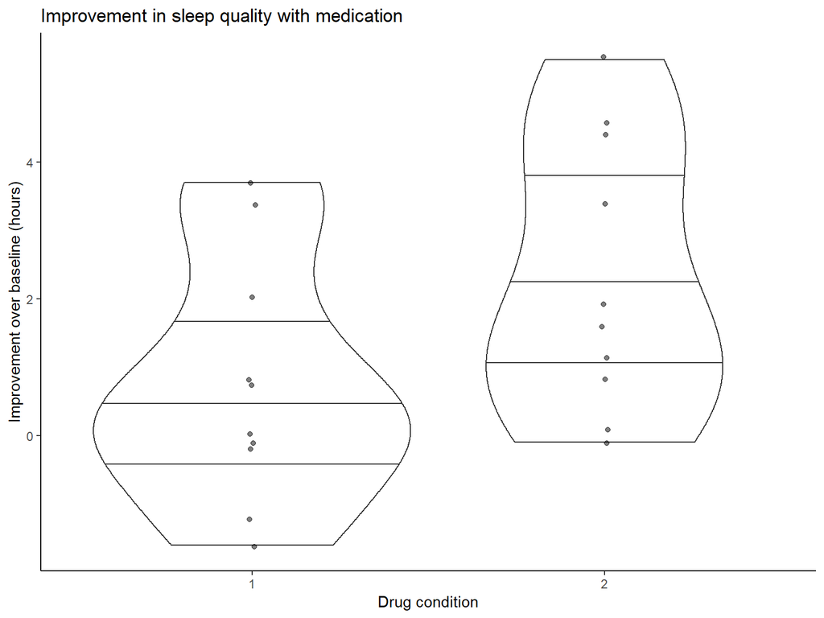

```r
ggplot(data=sleep, aes(x=group,y=extra)) +
  geom_violin(draw_quantiles=c(.25,.5,.75))+
  geom_jitter(width=.01,alpha=.5)  + theme_classic() +
  ggtitle("Improvement in sleep quality with medication") +
  ylab("Improvement over baseline (hours)") + xlab("Drug condition")
```

## Box plot

Distribution of Y over X

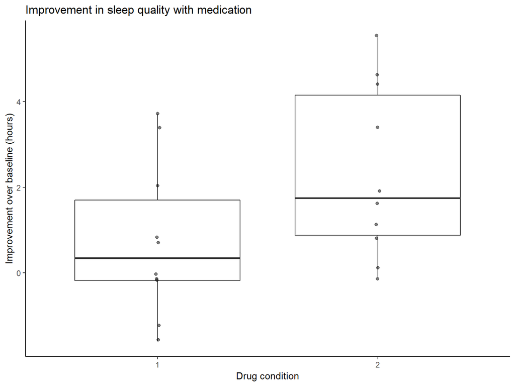

```r
ggplot(data=sleep, aes(x=group,y=extra)) +
  geom_boxplot()+
  geom_jitter(width=.01,alpha=.5)  + theme_classic() +
  ggtitle("Improvement in sleep quality with medication") +
  ylab("Improvement over baseline (hours)") + xlab("Drug condition")
```

## Density plot

Distribution of Y over X

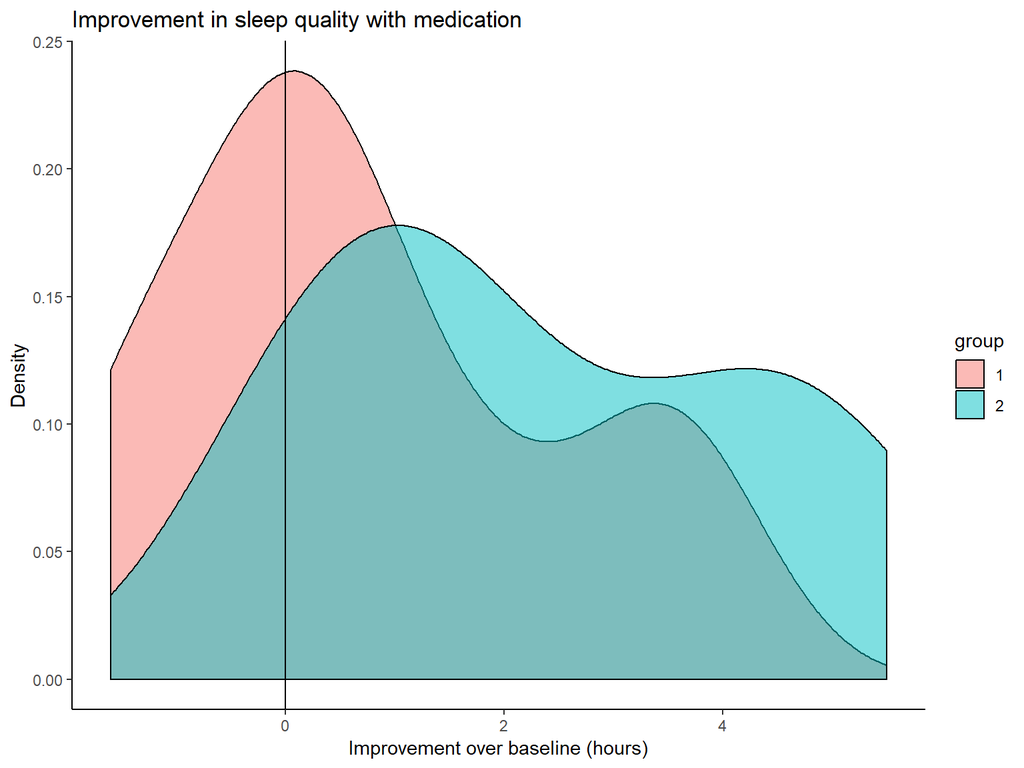

```r
ggplot(data=sleep, aes(x=extra,fill=group)) +
  geom_density(alpha=.5)+  theme_classic() +
  geom_vline(xintercept=0)+
  ggtitle("Improvement in sleep quality with medication") +
  xlab("Improvement over baseline (hours)") + ylab("Density")
```

## Histogram

Distribution of Y over X

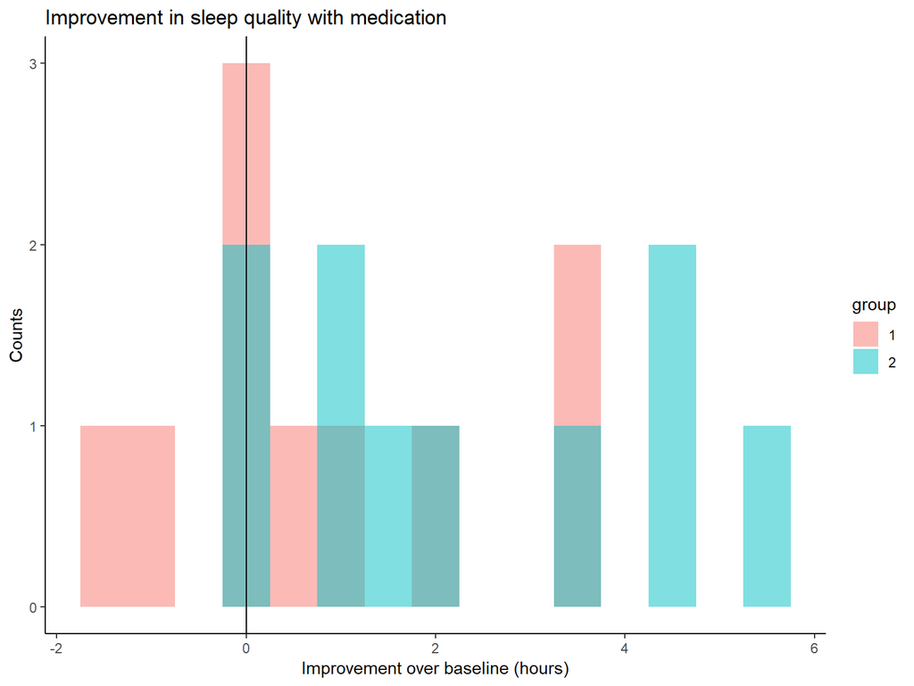

```r
ggplot(data=sleep, aes(x=extra,fill=group)) +
  geom_histogram(alpha=.5,position="identity",binwidth=.5)+  theme_classic() +
  geom_vline(xintercept=0)+
  ggtitle("Improvement in sleep quality with medication") +
  xlab("Improvement over baseline (hours)") + ylab("Counts")
```

## Part to whole

Question: “How does the value of Y change between categories of X”

(*Only* appropriate for categorical variables)

- Pie charts can be quite confusing, unless you’ve got one very clear majority.
  - This is because they require relational comparisons
- Bar plots / stacked bar plots are OK for proportion data
  - Ok to hide nuances
  - Simple plot is fast and easy to perceive
- Bar plots are not good for other types of data
  - Sometime simple is not a good representation of the data
  - Overstates conclusions that aren’t really there

## BarBarplots

This plot isn’t terrible. The data have a meanigful zero, and the range does start around there. But, the boxplot is as easy to read and portrays more information!

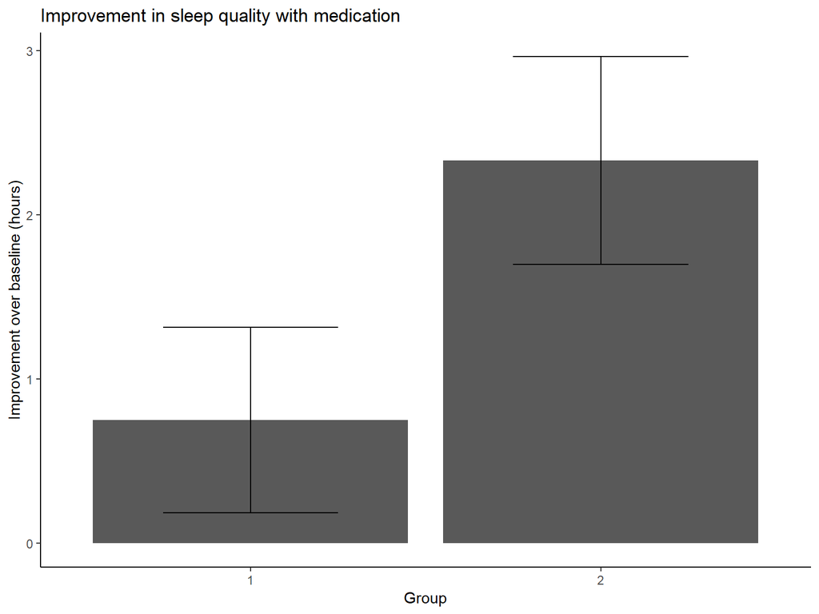

```r
sleep2 <- sleep %>% group_by(group) %>%
  summarise(mExtra = mean(extra),seExtra=sd(extra)/sqrt(n()))%>%
  mutate(seD = mExtra - seExtra,
        seU = mExtra + seExtra)

ggplot(data=sleep2, aes(x=group,y=mExtra)) +
  geom_bar(stat="identity")+ geom_errorbar(aes(ymin=seD,ymax=seU),width=.5)+
  theme_classic() +
  ggtitle("Improvement in sleep quality with medication") +
  ylab("Improvement over baseline (hours)") + xlab("Group")
```

## Ok Barplots

Here’s a subtle improvement: tabulate the data so that we plot the proportion of individuals with improved sleep quality by group. If that’s the actual question we’re interested in, this might be the right plot. Why: The data all exist between 0 and 1, which are the limits on the scale.

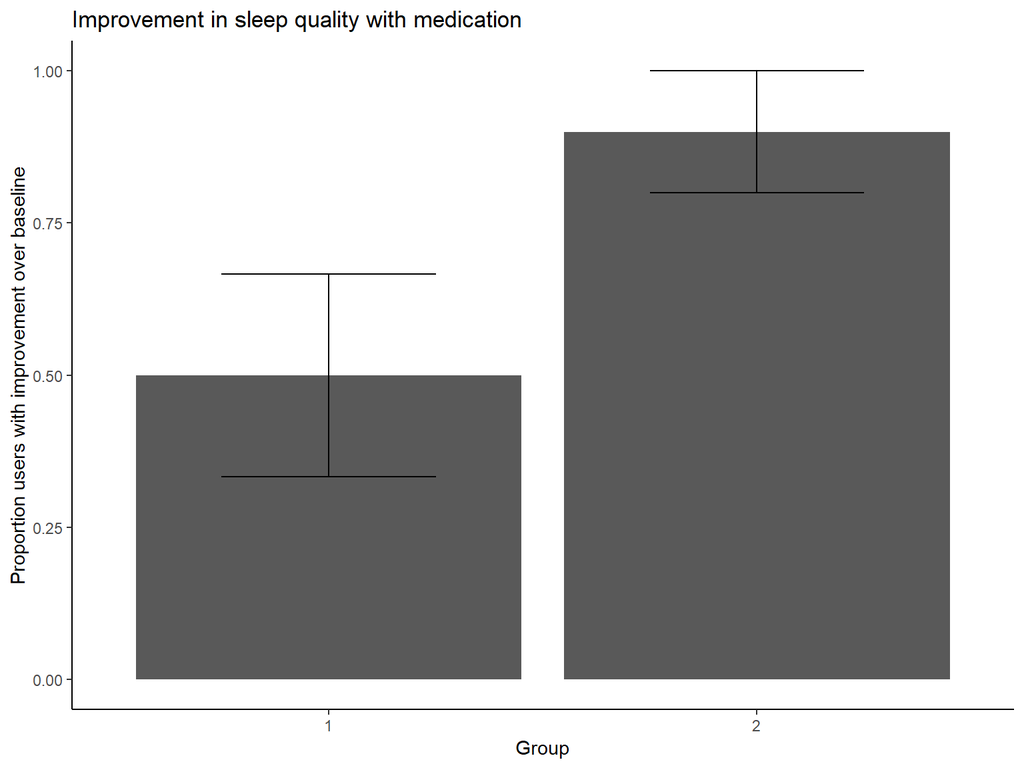

```r
sleep3 <- sleep %>% group_by(group) %>%
 mutate(Improved = ifelse(extra > 0, 1, 0)) %>%
 summarise(mImp = mean(Improved), seImp=sd(Improved/sqrt(n()))) %>%
  mutate(seD = mImp - seImp,
        seU = mImp + seImp)


ggplot(data=sleep3, aes(x=group,y=mImp)) +
  geom_bar(stat="identity")+
  geom_errorbar(aes(ymin=seD,ymax=seU),width=.5)+
  theme_classic() +
  ggtitle("Improvement in sleep quality with medication") +
  ylab("Proportion users with improvement over baseline") + xlab("Group")
```

## Sum-up

- There are many plot options, play around with them!
- Portray variability when you can, but also tell a clear story
  - use greyscale, alter alphas, add trend lines, other ‘shorthands’
  - adding points is a great way to show variability, but sometimes can be overwheliming
- When in doubt: defualy to a density plot or a violin.